# Proyecto Médodos II

## Clustering jerárquico agregativo

Los métodos jerárquicos agregativos son una técnica de análisis multivariante que permiten la agrupación de observaciones en clústeres. Estos métodos se basan en la idea de que las observaciones más similares deben agruparse juntas y las menos similares deben separarse. En la práctica, este método comienza con cada observación en su propio grupo y, a continuación, combinan gradualmente los grupos más similares hasta que se alcanza un único grupo que contiene todas las instancias u observaciones. Este proceso de agrupamiento se representa mediante un dendrograma, que es una representación gráfica de la estructura jerárquica de los grupos, nuestro caso no mostramos está representación por la cantidad de datos.

```r
data_NCCo <- NbClust(data2[,-11], method = "complete")
```

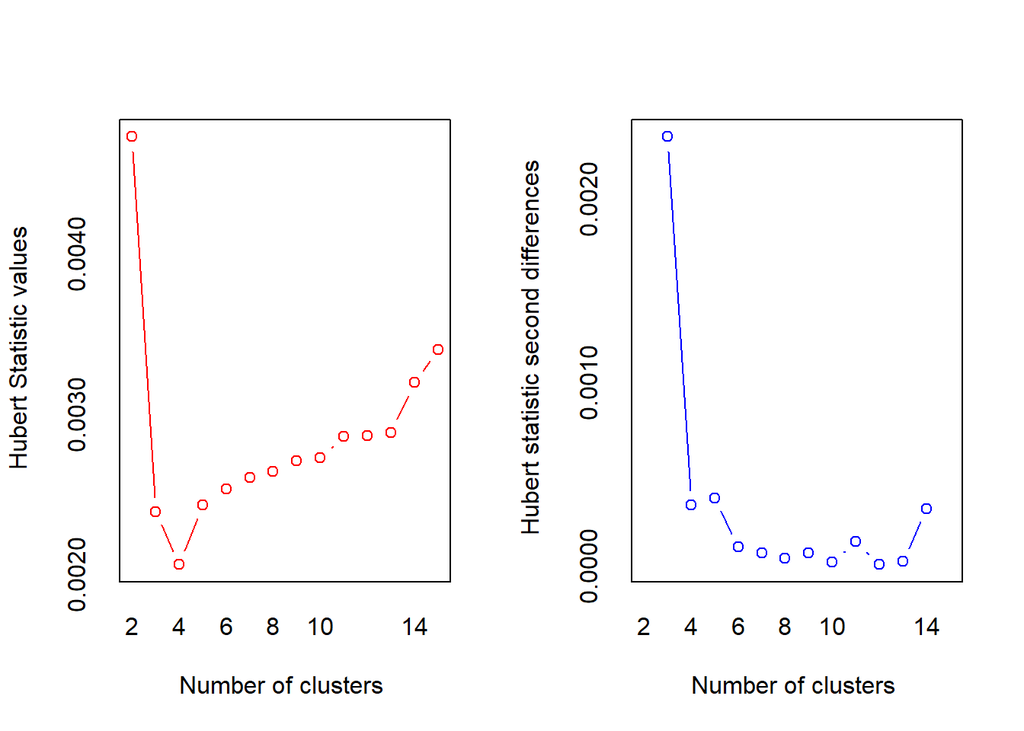

```
## *** : The Hubert index is a graphical method of determining the number of clusters.
##                 In the plot of Hubert index, we seek a significant knee that corresponds to a
##                 significant increase of the value of the measure i.e the significant peak in Hubert
##                 index second differences plot.
##
```

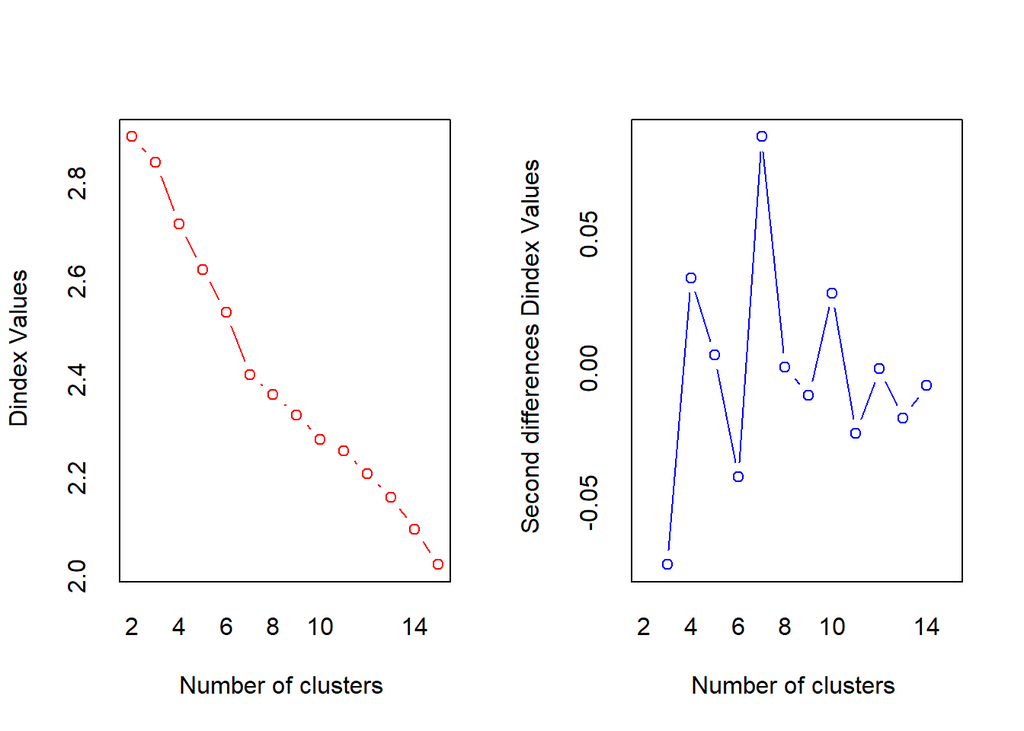

```
## *** : The D index is a graphical method of determining the number of clusters.
##                 In the plot of D index, we seek a significant knee (the significant peak in Dindex
##                 second differences plot) that corresponds to a significant increase of the value of
##                 the measure.
##
## * Among all indices:
## * 11 proposed 2 as the best number of clusters
## * 1 proposed 3 as the best number of clusters
## * 1 proposed 4 as the best number of clusters
## * 3 proposed 6 as the best number of clusters
## * 5 proposed 7 as the best number of clusters
## * 1 proposed 13 as the best number of clusters
## * 2 proposed 15 as the best number of clusters
##
##                    ***** Conclusion *****
##
## * According to the majority rule, the best number of clusters is  2
##
##
```

```r
data_NCS <- NbClust(data2[,-11], method = "single")
```

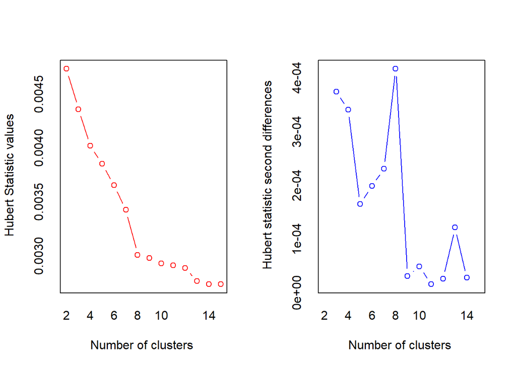

```
## *** : The Hubert index is a graphical method of determining the number of clusters.
##                 In the plot of Hubert index, we seek a significant knee that corresponds to a
##                 significant increase of the value of the measure i.e the significant peak in Hubert
##                 index second differences plot.
##
```

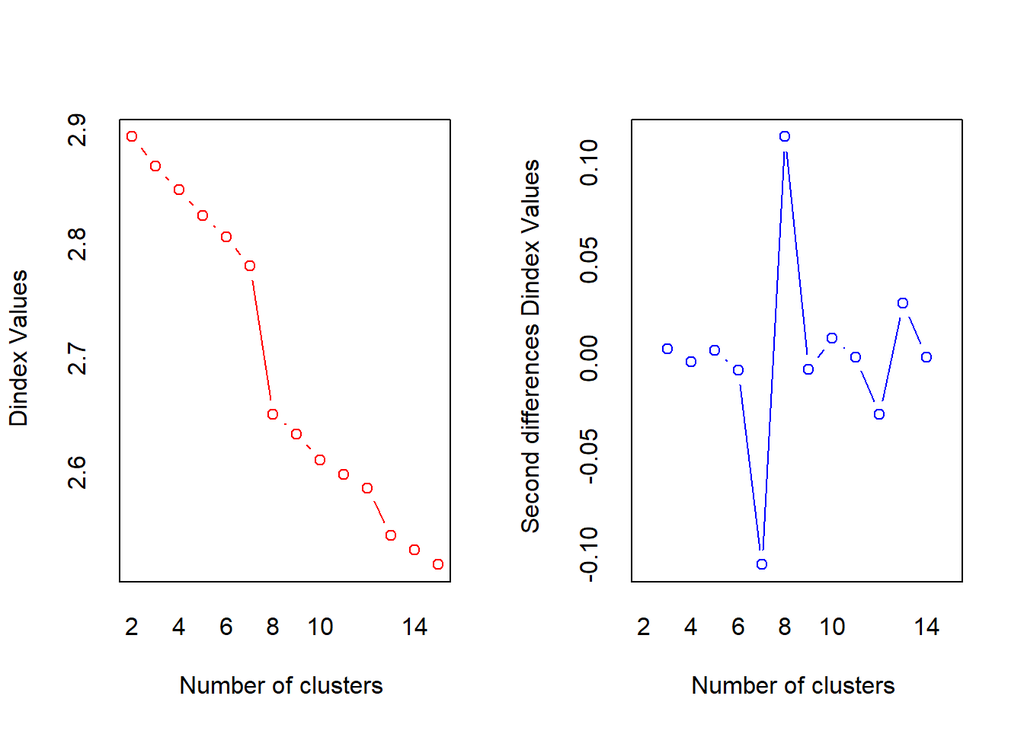

```
## *** : The D index is a graphical method of determining the number of clusters.
##                 In the plot of D index, we seek a significant knee (the significant peak in Dindex
##                 second differences plot) that corresponds to a significant increase of the value of
##                 the measure.
##
## * Among all indices:
## * 8 proposed 2 as the best number of clusters
## * 3 proposed 3 as the best number of clusters
## * 1 proposed 6 as the best number of clusters
## * 10 proposed 8 as the best number of clusters
## * 2 proposed 9 as the best number of clusters
##
##                    ***** Conclusion *****
##
## * According to the majority rule, the best number of clusters is  8
##
##
```

```r
data_NCA <- NbClust(data2[,-11], method = "average")
```

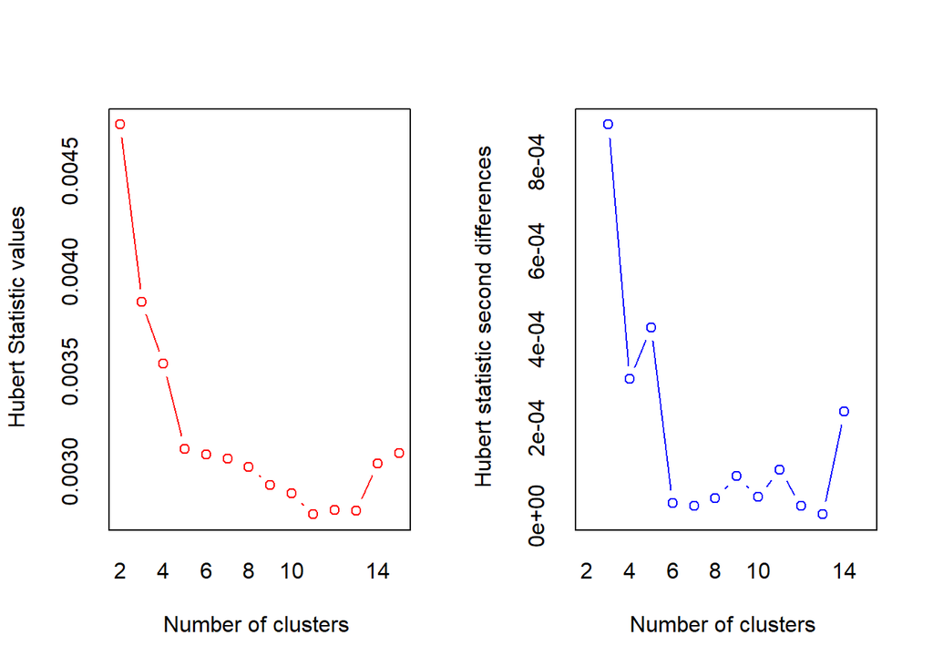

```
## *** : The Hubert index is a graphical method of determining the number of clusters.
##                 In the plot of Hubert index, we seek a significant knee that corresponds to a
##                 significant increase of the value of the measure i.e the significant peak in Hubert
##                 index second differences plot.
##
```

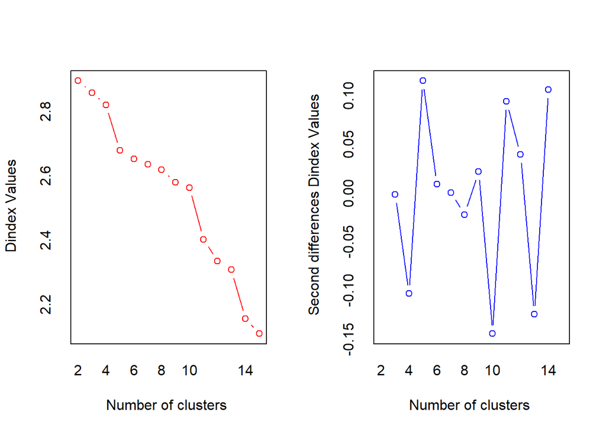

```
## *** : The D index is a graphical method of determining the number of clusters.
##                 In the plot of D index, we seek a significant knee (the significant peak in Dindex
##                 second differences plot) that corresponds to a significant increase of the value of
##                 the measure.
##
## * Among all indices:
## * 9 proposed 2 as the best number of clusters
## * 1 proposed 3 as the best number of clusters
## * 4 proposed 5 as the best number of clusters
## * 3 proposed 10 as the best number of clusters
## * 1 proposed 12 as the best number of clusters
## * 1 proposed 13 as the best number of clusters
## * 3 proposed 14 as the best number of clusters
## * 2 proposed 15 as the best number of clusters
##
##                    ***** Conclusion *****
##
## * According to the majority rule, the best number of clusters is  2
##
##
```

```r
data_NCCe <- NbClust(data2[,-11], method = "centroid")
```

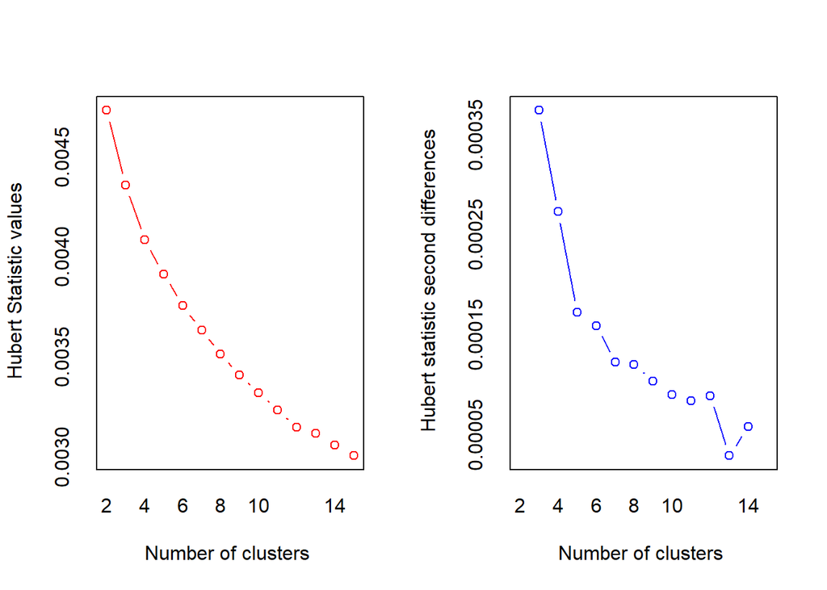

```
## *** : The Hubert index is a graphical method of determining the number of clusters.
##                 In the plot of Hubert index, we seek a significant knee that corresponds to a
##                 significant increase of the value of the measure i.e the significant peak in Hubert
##                 index second differences plot.
##
```

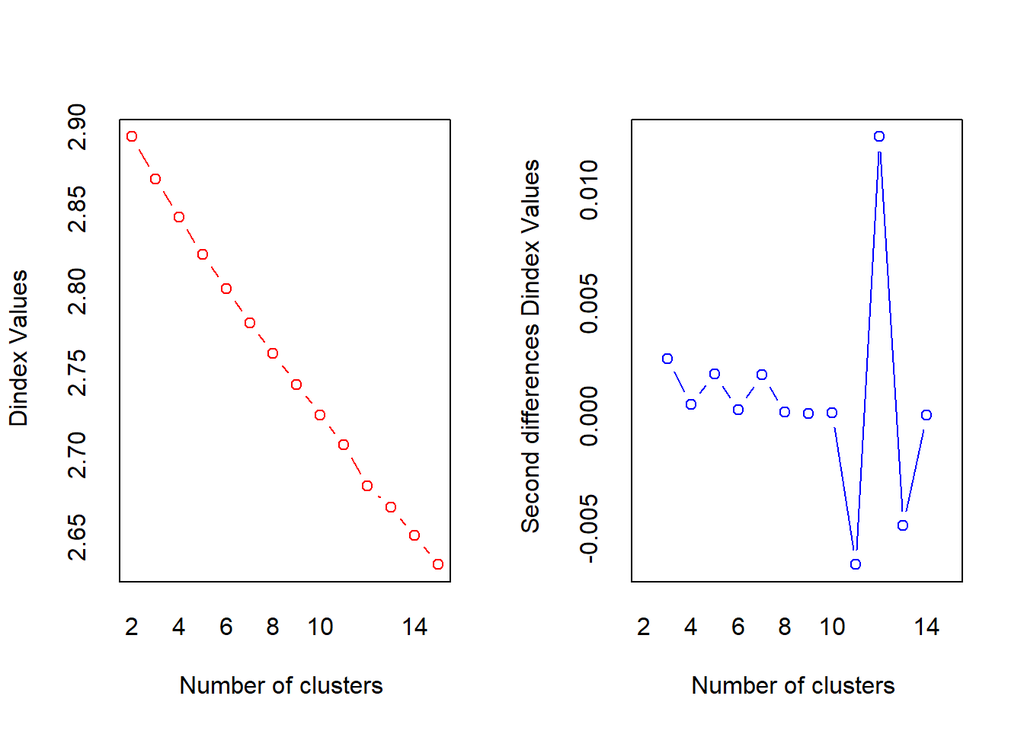

```
## *** : The D index is a graphical method of determining the number of clusters.
##                 In the plot of D index, we seek a significant knee (the significant peak in Dindex
##                 second differences plot) that corresponds to a significant increase of the value of
##                 the measure.
##
## * Among all indices:
## * 9 proposed 2 as the best number of clusters
## * 4 proposed 3 as the best number of clusters
## * 1 proposed 4 as the best number of clusters
## * 1 proposed 5 as the best number of clusters
## * 2 proposed 11 as the best number of clusters
## * 5 proposed 12 as the best number of clusters
## * 2 proposed 15 as the best number of clusters
##
##                    ***** Conclusion *****
##
## * According to the majority rule, the best number of clusters is  2
##
##
```

```r
#data_NCA
data_NCA$Best.partition
```

```
##   2   3   4   5   7   9  10  11  13  14  15  16  17  18  19  20  21  22  25  26
##   1   1   1   1   1   1   1   1   1   1   1   1   1   1   1   1   1   1   1   1
##  27  28  30  32  33  34  35  37  39  41  42  43  44  46  48  49  50  51  53  54
##   1   1   1   1   1   1   1   1   1   1   1   1   1   1   1   1   1   1   1   1
##  55  56  57  58  59  61  62  63  66  67  69  70  72  73  74  75  76  77  78  80
##   1   1   1   1   1   1   1   1   1   1   1   1   1   1   1   1   1   1   1   1
##  81  82  84  85  86  87  88  89  90  92  93  94  95  98  99 100 101 102 103 105
##   1   1   1   1   1   1   1   1   1   1   1   1   1   1   1   1   1   1   1   1
## 107 110 111 112 115 116 117 122 124 125 128 129 130 131 132 133 134 135 138 139
##   1   1   1   1   1   1   1   1   1   1   1   1   1   1   1   1   1   1   1   1
## 140 141 142 143 144 145 147 148 149 150 151 152 155 156 157 159 160 162 163 164
##   1   1   1   1   1   1   1   1   1   1   1   2   1   1   1   1   1   1   1   1
## 165 166 167 168 169 171 172 173 175 176 177 178 179 182 183 184 185 186 188 190
##   1   1   1   1   1   1   1   1   1   1   1   1   1   1   1   1   1   1   1   1
## 192 194 196 197 198 199 200 201 202 203 204 208 209 210 212 214 215 216 217 218
##   1   1   1   1   1   1   1   1   1   1   1   1   1   1   1   1   1   1   1   1
## 219 220 221 222 224 225 226 227 230 232 233 234 237 238 239 240 241 242 244 247
##   1   1   1   1   1   1   1   1   1   1   1   1   1   1   1   1   1   1   1   1
## 249 250 251 252 253 254 255 256 257 258 259 260 262 263 268 269 270 271 273 274
##   1   1   1   1   1   1   1   1   1   1   1   1   1   1   1   1   1   1   1   1
## 275 276 277 278 279 281 283 287 288 289 290 291 294 295 297 298 301 302
##   1   1   1   1   1   1   1   1   1   1   1   1   1   1   1   1   1   1
```

El mejor cluster identifica que el dataset presenta sesgo hacia una variable en particular.

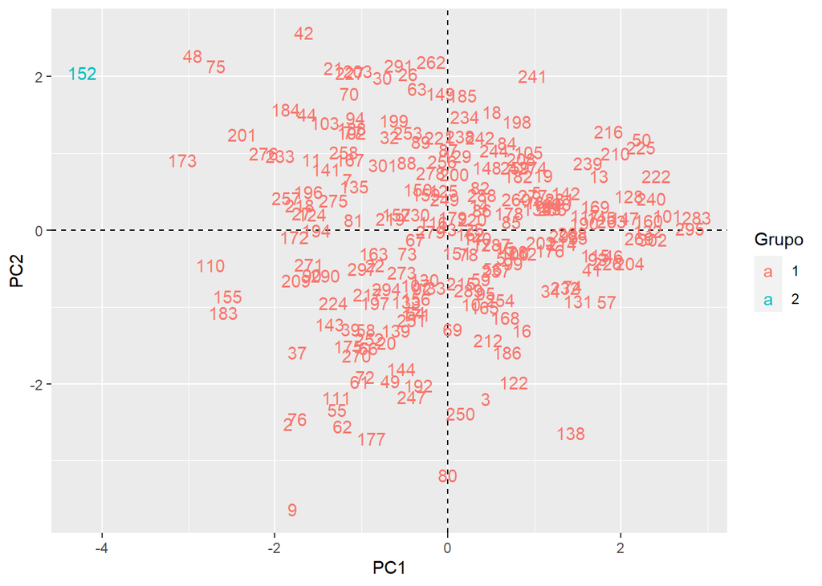

```r
data_pca <- prcomp(data2[,-11])
Grupo <- as.factor(
data_NCA$Best.partition
)
ggplot(as.data.frame(data_pca$x),
aes(x = PC1, y = PC2, color = Grupo,
label = rownames(data2))) +
geom_hline(yintercept = 0, lty = 2) +
geom_vline(xintercept = 0, lty = 2) +
geom_text()
```

Básicamente está realizando un solo grupo. La técnica funcionaría mejor si balanceamos los datos.

# Bibliografía

[1] W. Larry, All of Statistics, 1st ed. Springer Science, 2004. [2] R Core Team, ‘R: A Language and Environment for Statistical Computing’. Vienna, Austria, 2018. [Online]. Available: https://www.R-project.org/ [3] Rs. Team, ‘RStudio: Integrated Development Environment for R’. RStudio, Inc., 2022. [4] Higueras. H. Manuel, Notas de Clase. 2022. [5] E. Brian, H. Torsten, An Introduction to Applied Multivariate Analysis with R, 1st ed. Springer Science, 2011. [6] P. Daniel, Análisis de Datos Multivariantes, 2014.